# 1800s emigration to America

Oliver Hofman

2026-08-03

```r
knitr::opts_chunk$set(echo = TRUE)
library(tidyverse)
library(tidytext)
```

```r
library(ggwordcloud)
library(syuzhet)
library (stopwords)
library(ggplot2)
library(dplyr)
library(readr)
```

# Loading the data into R

using Swagger UI, a link is created from the search “(Amerika OR USA OR”de forenede Stater”) AND (udvandre* OR emigr*) AND py:[1840 TO 1880] NOT (Thingvalla OR “Allan Line” OR Cunard)”

```r
link <-"https://labs.statsbiblioteket.dk/labsapi/api/aviser/export/fields?query=%28Amerika%20OR%20USA%20OR%20%22de%20forenede%20Stater%22%29%20AND%20%28udvandre%2A%20OR%20emigr%2A%29%20AND%20py%3A%5B1840%20TO%201880%5D%20NOT%20%28Thingvalla%20OR%20%22Allan%20Line%22%20OR%20Cunard%29&fields=link&fields=recordID&fields=timestamp&fields=pwa&fields=cer&fields=fulltext_org&fields=pageUUID&fields=editionUUID&fields=titleUUID&fields=editionId&fields=familyId&fields=newspaper_page&fields=newspaper_edition&fields=lplace&fields=location_name&fields=location_coordinates&max=-1&structure=header&structure=content&format=CSV"

URLdecode(link)
```

```
## [1] "https://labs.statsbiblioteket.dk/labsapi/api/aviser/export/fields?query=(Amerika OR USA OR \"de forenede Stater\") AND (udvandre* OR emigr*) AND py:[1840 TO 1880] NOT (Thingvalla OR \"Allan Line\" OR Cunard)&fields=link&fields=recordID&fields=timestamp&fields=pwa&fields=cer&fields=fulltext_o…
```

```r
NewsP_1800s <- read.csv(link)
```

# Analysing the datas origin

Here its seen that Copenhagen is in the clear lead, with quite the drop to the next most. it also shows that “Dagstelegraphen” is the paper with most mentions.

```r
NewsP_1800s %>%
  count(lplace, sort = TRUE)
```

```
##              lplace    n
## 1         København 6955
## 2           Horsens 2162
## 3  Nykøbing Falster 1744
## 4            Aarhus 1244
## 5            Odense 1215
## 6             Vejle 1195
## 7          Slagelse 1059
## 8             Rønne  994
## 9         Haderslev  913
## 10        Svendborg  704
## 11         Ringsted  695
## 12       Middelfart  531
## 13        Silkeborg  524
## 14            Århus  518
```

[output cut: 29 more lines]

```r
NewsP_1800s %>%
  count(familyId, sort = TRUE)
```

```
##                        familyId    n
## 1               dagstelegraphen 1903
## 2  lollandfalstersstiftstidende 1536
## 3            fyensstiftstidende 1215
## 4          horsensfolkeblad1866 1197
## 5            vejleamtsfolkeblad 1195
## 6             berlingsketidende 1157
## 7               horsensavis1828  965
## 8           aarhusstiftstidende  903
## 9     sjaellandstidendeslagelse  859
## 10               dannevirke1867  646
## 11                  flyveposten  622
## 12              folketsavis1860  585
## 13                bornholmsavis  540
## 14           middelfartavis1857  531
```

[output cut: 62 more lines]

#Textmining Here the articles are divided up into singular words and then edited by using 2 lists of stopwords pertaining to 1800s danish and modern danish

```r
# Tokenize the newspaper text
NewsP_1800s_tidy <- NewsP_1800s %>%
  unnest_tokens(word, fulltext_org)

# Read the 1800s stopword list
stopwords_1800s <- read_csv(
  "https://gist.githubusercontent.com/maxodsbjerg/1537cf14c3d46b3d30caa5d99f8758e9/raw/9f044a38505334f035be111c9a3f654a24418f6d/stopord_18_clean.csv",
  show_col_types = FALSE
)

# Load modern Danish stopwords
stopwords_modern <- tibble(
  word = stopwords::stopwords("da")
)

# Combine the two stopword lists and remove duplicates
stopwords_all <- bind_rows(
  stopwords_1800s,
  stopwords_modern
) %>%
  distinct(word)

# Remove all stopwords and count the remaining words
NewsP_1800s_wStopwords <- NewsP_1800s_tidy %>%
  anti_join(stopwords_all, by = "word") %>%
  count(word, sort = TRUE)
```

#Removing numerals and creating a top 100 Here numbers are filtered out, as to only get actual words that can be analysed. Then its put into a top 100 of most mentions

```r
NewsP_1800s_nonum <- NewsP_1800s_wStopwords %>%
filter(!str_detect(word, "[0-9]"))

 NewsP_1800s_top100 <- head(NewsP_1800s_nonum, 100)

 NewsP_1800s_top100
```

```
##             word     n
## 1        amerika 35621
## 2     udvandrere 15461
## 3          siden  9966
## 4           hver  8922
## 5        tilbage  8126
## 6            kom  8003
## 7            faa  7962
## 8           stal  7936
## 9         bleven  7787
## 10    kjobenhavn  7720
## 11        mellem  7656
## 12           vel  7606
## 13            vg  7350
## 14            kr  7257
```

[output cut: 86 more lines]

#Wordcloud by creating a wordcloud with the top 100, its made easier to visualize whats mentioned the most.

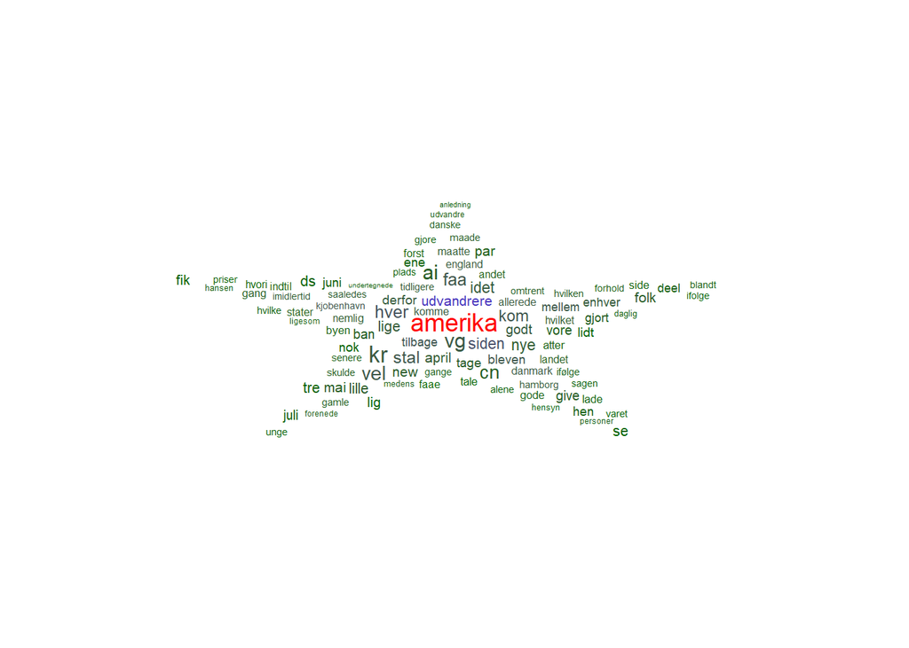

```r
ggplot(data = NewsP_1800s_top100, aes(label = word, size = n)) +
  geom_text_wordcloud_area(aes(color = n), shape = "star") +
  scale_size_area(max_size = 12) +
  scale_color_gradientn(colors = c("darkgreen","blue","red")) +
  theme_minimal()
```

#Sentiment analysis here the words get joined together back into the whole article, as to get a overall sentiment score from the articles.

```r
fulltext_tidy_recordID <- NewsP_1800s_tidy %>%
  anti_join(stopwords_1800s, by = c("word" = "word")) %>%
  group_by(recordID) %>%
  summarise(fulltext_clean = paste(word, collapse = " "), .groups = "drop")

sentiment_text_recordID <- fulltext_tidy_recordID %>%
  mutate(
    fulltext_sentiment = map_dbl(
      fulltext_clean,
      function(x) get_sentiment(x, method = "afinn")
    )
  )
sentiment_by_record_1800s <- sentiment_text_recordID %>%
  group_by(recordID) %>%
  summarise(
    mean_sentiment = mean(fulltext_sentiment, na.rm = TRUE),
    n = n()
  )
```

#Visualizing the Sentiment here the articles sentiment score is plotted into a histogram to better visualize the spread of sentiment across all the articles

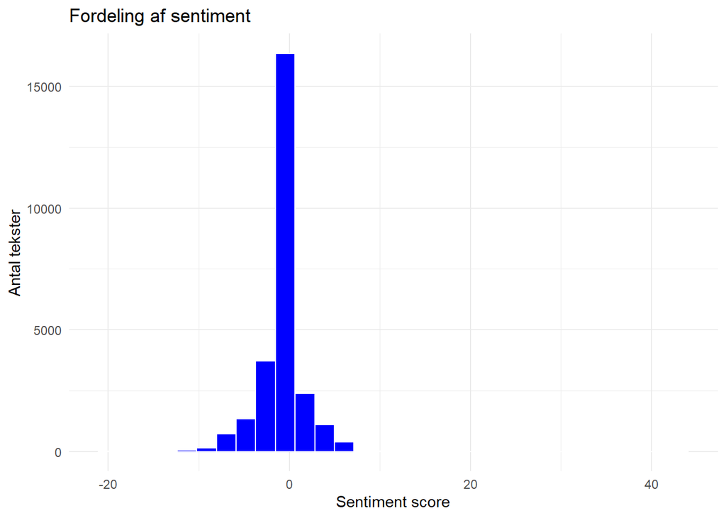

```r
library(ggplot2)

ggplot(sentiment_by_record_1800s,
       aes(x = mean_sentiment)) +
  geom_histogram(bins = 30,
                 fill = "Blue",
                 color = "white") +
  theme_minimal() +
  labs(
    title = "Fordeling af sentiment",
    x = "Sentiment score",
    y = "Antal tekster"
  )
```

```r
ggsave("histogram 1800s.png", width = 8, height = 6, dpi = 300)
```

#Average Sentiment Score here a average of the sentiment is calculated

```r
mean(sentiment_by_record_1800s$mean_sentiment,
     na.rm = TRUE)
```

```
## [1] -0.5234619
```

#Categorizing the sentiment by dividing all the articles into 3 Categories, “Positiv”, “Negativ” and “Neutral” and counting how many of the articles land into each categories

```r
sentiment_CAT_1800s <- sentiment_by_record_1800s %>%
  mutate(sentiment_category = case_when(
    mean_sentiment > 0 ~ "Positiv",
    mean_sentiment < 0 ~ "Negativ",
    TRUE ~ "Neutral"
  ))

sentiment_CAT_1800s %>%
  count(sentiment_category)
```

```
## # A tibble: 3 × 2
##   sentiment_category     n
##   <chr>              <int>
## 1 Negativ             7497
## 2 Neutral            14882
## 3 Positiv             3919
```